# Data-624 Homework-8

## —————————————————————————

### **Student Name :** Sachid Deshmukh

### **Date :** 04/23/2020

- > [RPubs location of published file](http://rpubs.com/sachid/Data624-Homework8)

## —————————————————————————

## 7.2

### Load data

```r
set.seed(200)
trainingData = mlbench.friedman1(200, sd=1)
trainingData$x = data.frame(trainingData$x)
testData = mlbench.friedman1(5000, sd=1)
testData$x = data.frame(testData$x)
```

### Tune several model on this data

```r
model.eval = function(modelmethod, gridSearch = NULL)
{
  Model = train(x = trainingData$x, y = trainingData$y, method = modelmethod, tuneGrid = gridSearch, preProcess = c('center', 'scale'), trControl = trainControl(method='cv'))
  Pred = predict(Model, newdata = testData$x)
  modelperf = postResample(Pred, testData$y)
  print(modelperf)
}
```

### 1] K-Nearest Neighbors -

```r
perfknn = model.eval('knn')
```

```
##      RMSE  Rsquared       MAE
## 3.1172319 0.6556622 2.4899907
```

### 2] Neural Net -

```r
nnetGrid = expand.grid(decay = c(0,0.01, .1), size = c(1:10))
perfnn = model.eval('nnet', nnetGrid)
```

```
##     RMSE Rsquared      MAE
## 14.27693       NA 13.38691
```

### 3] Support Vector Machine -

```r
perfsvm = model.eval('svmRadial')
```

```
##      RMSE  Rsquared       MAE
## 2.2552633 0.7994934 1.7222081
```

### 4] Multivariate Adaptive Regression Splines -

```r
marsGrid = expand.grid(degree = 1:2, nprune = 2:38)
perfmars = model.eval('earth', marsGrid)
```

```
##      RMSE  Rsquared       MAE
## 1.3061003 0.9308395 1.0385604
```

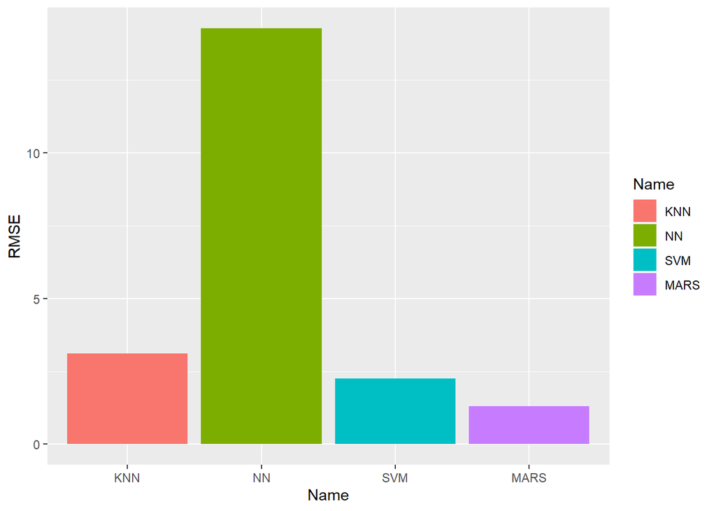

```r
df.perf = rbind(data.frame(Name = 'KNN', RMSE = perfknn[1]), data.frame(Name= 'NN', RMSE = perfnn[1]) , data.frame(Name = 'SVM', RMSE = perfsvm[1]), data.frame(Name = 'MARS', RMSE = perfmars[1]))

ggplot() +
  geom_bar(data = df.perf, aes(x = Name, y = RMSE, fill=Name), stat="identity")
```

### Which models appear to give the best performance?

#### From the above bar chart we can see that MARS model gives us best RMSE on test set

### Does MARS select informative predictors (those named X1-X5)

```r
marsGrid = expand.grid(degree = 1:2, nprune = 2:38)
MARSModel = train(x = trainingData$x, y = trainingData$y, method = 'earth', tuneGrid = marsGrid, preProcess = c('center', 'scale'), trControl = trainControl(method='cv'))
varImp(MARSModel)
```

```
## earth variable importance
##
##     Overall
## X1   100.00
## X4    84.98
## X2    68.87
## X5    48.55
## X3    38.96
## X9     0.00
## X8     0.00
## X10    0.00
## X7     0.00
## X6     0.00
```

#### From the above variable importance table we can see that MARS model is selecting informative predictors (those named X1-X5)

## 7.5

### Prepare Data

```r
library(AppliedPredictiveModeling)
data(ChemicalManufacturingProcess)
tmp.data <- mice(ChemicalManufacturingProcess,m=2,maxit=5,meth='pmm',seed=500)
ChemicalManufacturingProcess = complete(tmp.data)

# train test split
set.seed(100)
rows = nrow(ChemicalManufacturingProcess)
t.index <- sample(1:rows, size = round(0.75*rows), replace=FALSE)
df.train <- ChemicalManufacturingProcess[t.index ,]
df.test <- ChemicalManufacturingProcess[-t.index ,]
df.train.x = df.train[,-1]
df.train.y = df.train[,1]
df.test.x = df.test[,-1]
df.test.y = df.test[,1]
```

```r
model.eval = function(modelmethod, gridSearch = NULL)
{
  Model = train(x = df.train.x, y = df.train.y, method = modelmethod, tuneGrid = gridSearch, preProcess = c('center', 'scale'), trControl = trainControl(method='cv'))
  Pred = predict(Model, newdata = df.test.x)
  modelperf = postResample(Pred, df.test.y)
  print(modelperf)
}
```

### 1] K-Nearest Neighbors -

```r
perfknn = model.eval('knn')
```

```
##      RMSE  Rsquared       MAE
## 1.2451733 0.4023846 0.9605909
```

### 2] Neural Net -

```r
nnetGrid = expand.grid(decay = c(0,0.01, .1), size = c(1:10))
perfnn = model.eval('nnet', nnetGrid)
```

```
##     RMSE Rsquared      MAE
## 39.32750       NA 39.29659
```

### 3] Support Vector Machine -

```r
perfsvm = model.eval('svmRadial')
```

```
##      RMSE  Rsquared       MAE
## 1.2104413 0.4357604 0.9917534
```

### 4] Multivariate Adaptive Regression Splines -

```r
marsGrid = expand.grid(degree = 1:2, nprune = 2:38)
perfmars = model.eval('earth', marsGrid)
```

```
##      RMSE  Rsquared       MAE
## 1.1162025 0.5346722 0.8678310
```

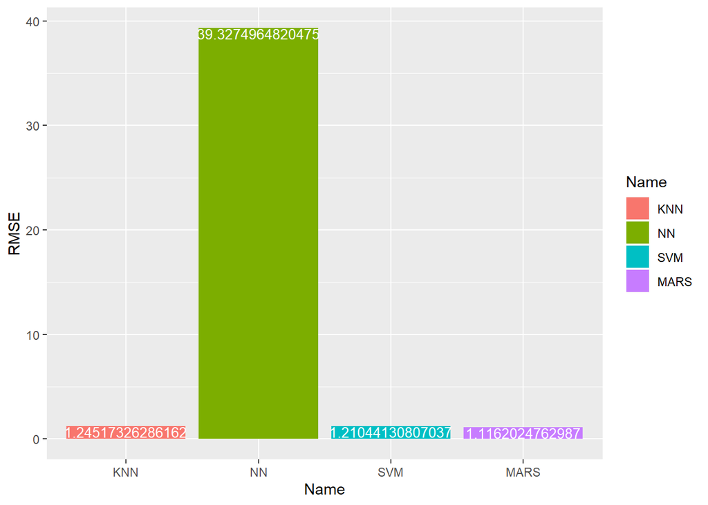

```r
df.perf = rbind(data.frame(Name = 'KNN', RMSE = perfknn[1]), data.frame(Name= 'NN', RMSE = perfnn[1]) , data.frame(Name = 'SVM', RMSE = perfsvm[1]), data.frame(Name = 'MARS', RMSE = perfmars[1]))

ggplot(data = df.perf, aes(x = Name, y = RMSE, fill=Name)) +
  geom_bar(stat="identity", position=position_dodge()) +
  geom_text(aes(label=RMSE), vjust=1, color="white",
            position = position_dodge(0.9), size=3.5)
```

### a. Which nonlinear regression model gives the optimal resampling and test set performance?

#### From the above bar plot we can see that second degree MARS model gives us optimal resampling and test set performance

### b. Which predictors are most important in the optimal nonlinear regression model? Do either the biological or process variables dominate the list? How do the top ten important predictors compare to the top ten predictors from the optimal linear model?

```r
marsGrid = expand.grid(degree = 1:2, nprune = 2:38)
MARSModel = train(x = df.train.x, y = df.train.y, method = 'earth', tuneGrid = marsGrid, preProcess = c('center', 'scale'), trControl = trainControl(method='cv'))
print(varImp(MARSModel))
```

```
## earth variable importance
##
##   only 20 most important variables shown (out of 57)
##
##                        Overall
## ManufacturingProcess32 100.000
## ManufacturingProcess09  70.413
## ManufacturingProcess13  70.251
## BiologicalMaterial02    57.591
## BiologicalMaterial06    50.058
## ManufacturingProcess17  39.753
## ManufacturingProcess42  31.938
## ManufacturingProcess43  29.620
## ManufacturingProcess28  28.164
## ManufacturingProcess06  22.935
## BiologicalMaterial07    16.488
## ManufacturingProcess05  16.488
## BiologicalMaterial10     7.311
## ManufacturingProcess39   0.000
## ManufacturingProcess04   0.000
## ManufacturingProcess20   0.000
## ManufacturingProcess33   0.000
## ManufacturingProcess26   0.000
## ManufacturingProcess08   0.000
## ManufacturingProcess24   0.000
```

#### From the above list of top 20 important variables we can see that manufacturing process variables dominate the important variable list.

```r
summary(MARSModel)
```

```
## Call: earth(x=data.frame[132,57], y=c(37.86,40.19,4...), keepxy=TRUE,
##             degree=2, nprune=15)
##
##                                                                           coefficients
## (Intercept)                                                                  38.759002
## h(-1.01489-BiologicalMaterial10)                                             -1.735577
## h(-0.225114-ManufacturingProcess17)                                           1.209577
## h(-1.26221-ManufacturingProcess32)                                            4.272698
## h(ManufacturingProcess32- -1.26221)                                           0.773730
## BiologicalMaterial07 * h(ManufacturingProcess05- -0.901682)                  -0.496288
## h(0.406326-BiologicalMaterial02) * h(ManufacturingProcess09- -0.96278)        2.272730
## h(BiologicalMaterial02-0.406326) * h(ManufacturingProcess09- -0.96278)        0.628935
## h(-0.327034-BiologicalMaterial06) * h(ManufacturingProcess05- -0.901682)     -0.853252
## h(-0.020428-BiologicalMaterial06) * h(ManufacturingProcess09- -0.96278)      -2.986868
## h(0.0730604-ManufacturingProcess06) * h(ManufacturingProcess09- -0.96278)    -0.799392
## h(-0.317952-ManufacturingProcess09) * h(ManufacturingProcess13- -1.34838)    -0.229493
## h(ManufacturingProcess09- -0.96278) * h(0.144637-ManufacturingProcess42)     -0.219491
## h(ManufacturingProcess13- -1.34838) * h(-0.6113-ManufacturingProcess43)      -1.159074
## h(0.775286-ManufacturingProcess28) * h(ManufacturingProcess32- -1.26221)      0.277827
##
## Selected 15 of 36 terms, and 13 of 57 predictors
## Termination condition: RSq changed by less than 0.001 at 36 terms
## Importance: ManufacturingProcess32, ManufacturingProcess09, ...
## Number of terms at each degree of interaction: 1 4 10
## GCV 0.834982    RSS 58.29693    GRSq 0.777723    RSq 0.8806302
```

### c. Explore the relationships between the top predictors and the response for the predictors that are unique to the optimal nonlinear regression model. Do these plots reveal intuition about the biological or process predictors and their relationship with yield?

#### Plot correltion matrix of data

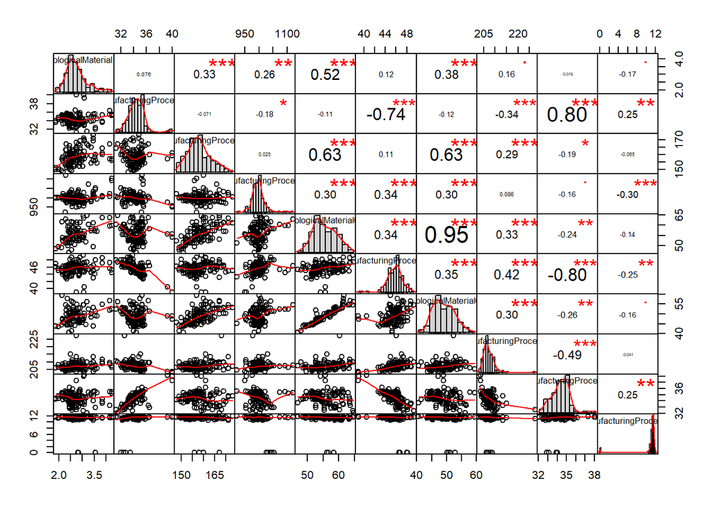